# 《R语言》第11章：多图组合

[返回课程主页](https://psychbruce.github.io/RCourse/)

授课教师：包寒吴霜

版权声明：本套课程材料开源，使用和分享必须遵守「创作共用许可协议 CC BY-NC-SA」（来源引用-非商业用途使用-以相同方式共享）。

# Chap11：多图组合

#### 往期要点回顾

- [Chap10 # 绘制变量分布](https://psychbruce.github.io/RCourse/Chap10#%E7%BB%98%E5%88%B6%E5%8F%98%E9%87%8F%E5%88%86%E5%B8%83)（直方图）
- [Chap10 # 绘制变量大小](https://psychbruce.github.io/RCourse/Chap10#%E7%BB%98%E5%88%B6%E5%8F%98%E9%87%8F%E5%A4%A7%E5%B0%8F)（柱形图）
- [Chap10 # 绘制变量关系](https://psychbruce.github.io/RCourse/Chap10#%E7%BB%98%E5%88%B6%E5%8F%98%E9%87%8F%E5%85%B3%E7%B3%BB)（散点图）
- [Chap10 # 绘制变量趋势](https://psychbruce.github.io/RCourse/Chap10#%E7%BB%98%E5%88%B6%E5%8F%98%E9%87%8F%E8%B6%8B%E5%8A%BF)（折线图）

#### 本章要点目录

- 【实践1】facet_wrap()：拆解分面小图
- 【实践2】facet_grid()：两个分类变量的交叉组合分面
- 【实践3】cowplot::plot_grid()：多图组合（重点）
- 【实践4】ggsave()：图形文件保存（重点）

```r
## 本章所需R包
library(bruceR)
# library(ggplot2)  # 加载bruceR时已默认加载ggplot2
# library(cowplot)  # 加载bruceR时已默认加载cowplot
```

# 分面小图

#### 【实践1】facet_wrap()：拆解分面小图

```r
## 数据准备
data = airquality
data$Month = as.factor(data$Month)
data$Temp.C = (data$Temp - 32) / 1.8  # 摄氏度 = (华氏度 - 32) / 1.8
str(data)
```

```
'data.frame':   153 obs. of  7 variables:
 $ Ozone  : int  41 36 12 18 NA 28 23 19 8 NA ...
 $ Solar.R: int  190 118 149 313 NA NA 299 99 19 194 ...
 $ Wind   : num  7.4 8 12.6 11.5 14.3 14.9 8.6 13.8 20.1 8.6 ...
 $ Temp   : int  67 72 74 62 56 66 65 59 61 69 ...
 $ Month  : Factor w/ 5 levels "5","6","7","8",..: 1 1 1 1 1 1 1 1 1 1 ...
 $ Day    : int  1 2 3 4 5 6 7 8 9 10 ...
 $ Temp.C : num  19.4 22.2 23.3 16.7 13.3 ...
```

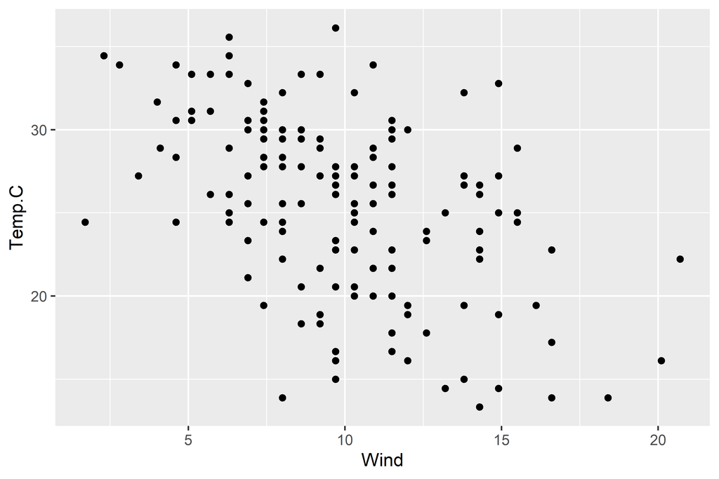

```r
## 基础散点图
ggplot(data, aes(x=Wind, y=Temp.C)) +
  geom_point()
```

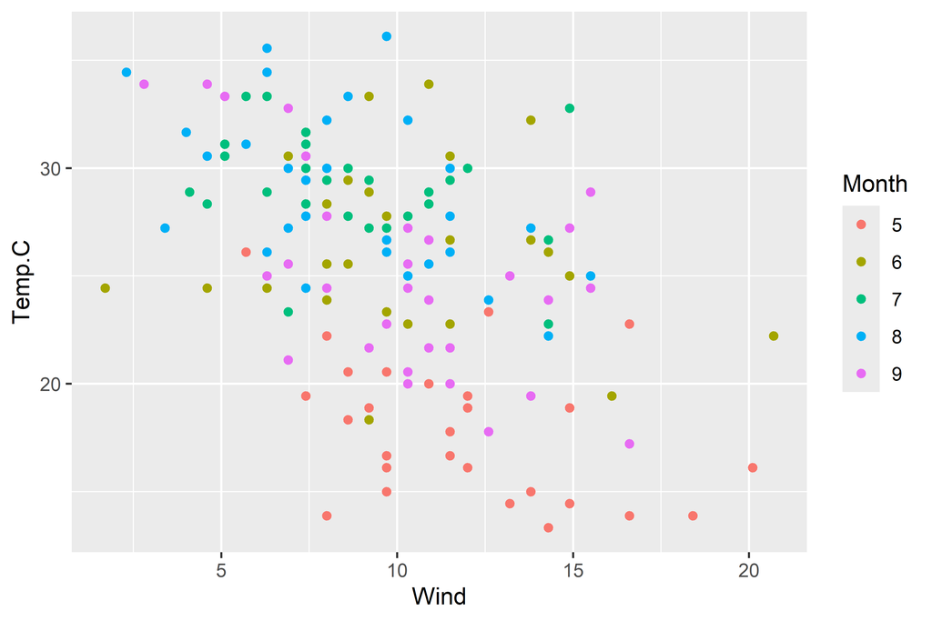

```r
ggplot(data, aes(x=Wind, y=Temp.C, color=Month)) +
  geom_point()
```

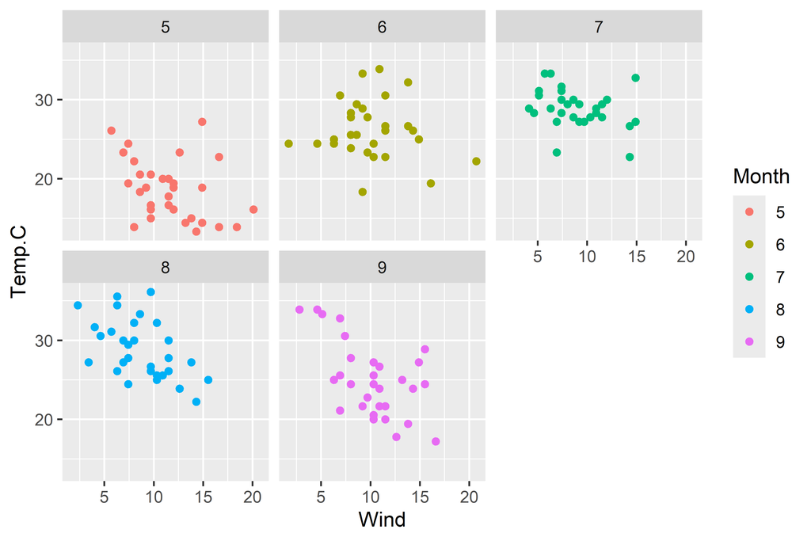

```r
ggplot(data, aes(x=Wind, y=Temp.C, color=Month)) +
  geom_point() +
  facet_wrap(~ Month)
```

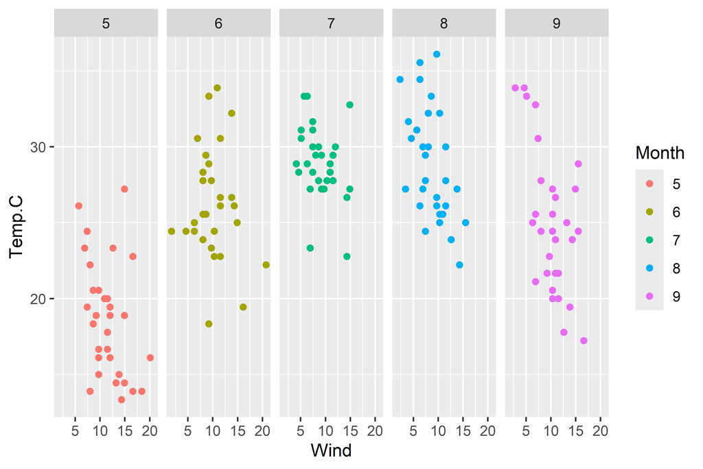

```r
ggplot(data, aes(x=Wind, y=Temp.C, color=Month)) +
  geom_point() +
  facet_wrap(~ Month, ncol=5)
```

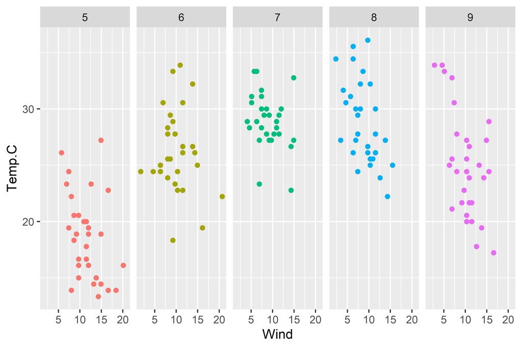

```r
ggplot(data, aes(x=Wind, y=Temp.C, color=Month)) +
  geom_point(show.legend=FALSE) +
  facet_wrap(~ Month, nrow=1)
```

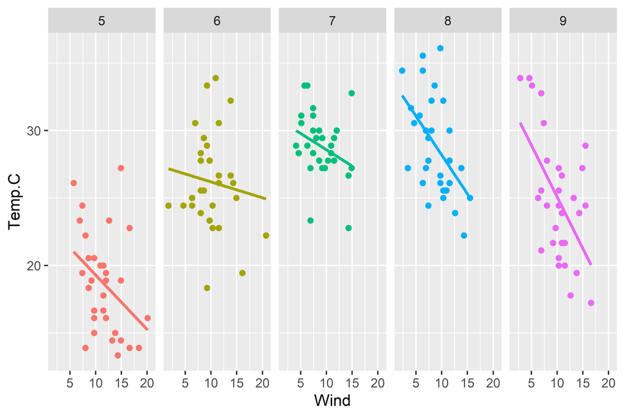

```r
ggplot(data, aes(x=Wind, y=Temp.C, color=Month)) +
  geom_point(show.legend=FALSE) +
  geom_smooth(method="lm", se=FALSE, show.legend=FALSE) +
  facet_wrap(~ Month, nrow=1)
```

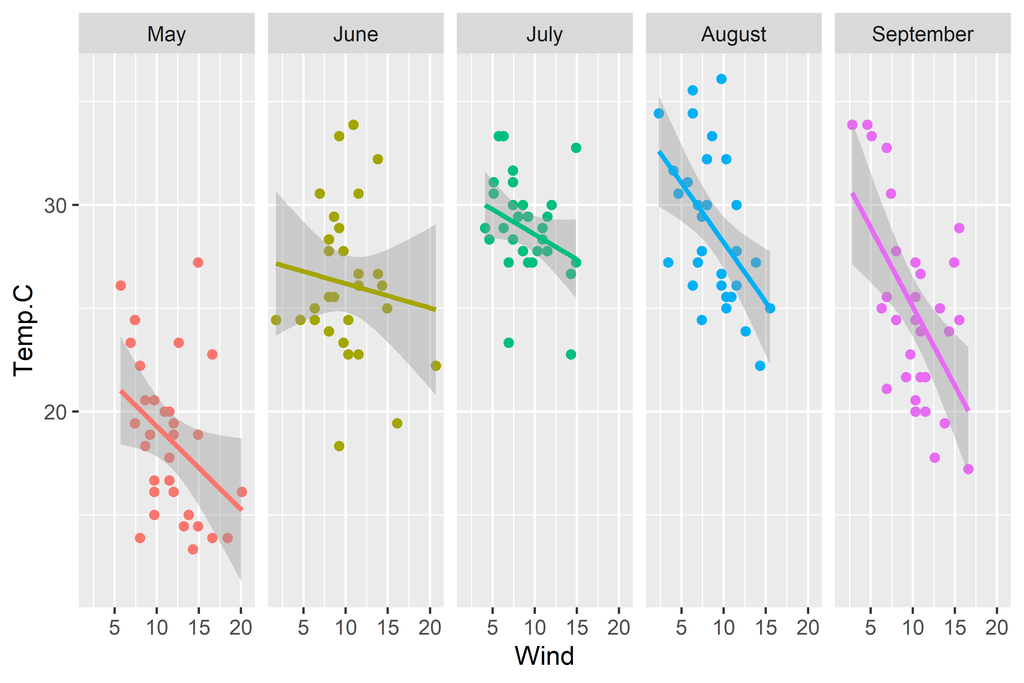

```r
## 修改因子标签
data$Months = factor(
  data$Month,
  levels = 5:9,
  labels = c("May", "June", "July", "August", "September")
)
ggplot(data, aes(x=Wind, y=Temp.C, color=Months)) +
  geom_point(show.legend=FALSE) +
  geom_smooth(method="lm", show.legend=FALSE) +
  facet_wrap(~ Months, nrow=1)
```

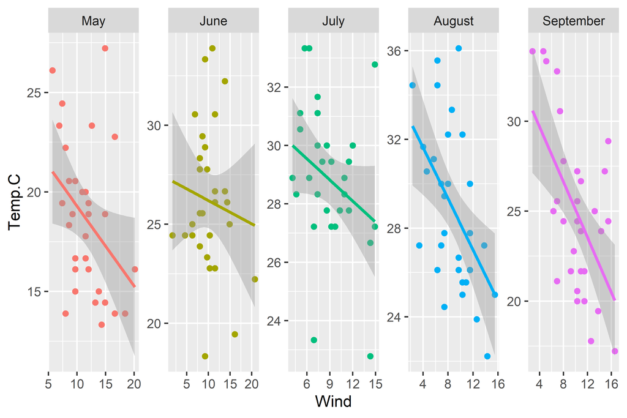

```r
ggplot(data, aes(x=Wind, y=Temp.C, color=Months)) +
  geom_point(show.legend=FALSE) +
  geom_smooth(method="lm", show.legend=FALSE) +
  facet_wrap(~ Months, nrow=1, scales="free")
```

#### 【实践2】facet_grid()：两个分类变量的交叉组合分面

- `facet_wrap()`：线性排列（卷饼🌯）
  - `~ 分组变量`
- `facet_grid()`：两因素交叉组合排列（华夫饼🧇）
  - `行分组变量 ~ 列分组变量`

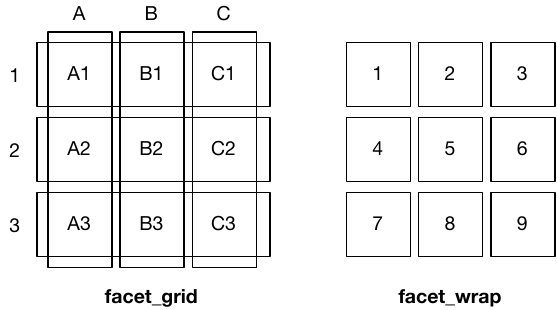

```r
## 两个分类变量的情况
## 数据变量计算复习（Chap 05 & 06）
data.bfi = as.data.table(psych::bfi)
data.bfi[, let(
  Gender = factor(gender, levels=1:2, labels=c("Male", "Female")),
  Age = as.numeric(age),
  Edu = as.factor(education),
  E = MEAN(data.bfi, "E", 1:5, rev=c(1,2), range=1:6),
  A = MEAN(data.bfi, "A", 1:5, rev=1, range=1:6),
  C = MEAN(data.bfi, "C", 1:5, rev=c(4,5), range=1:6),
  N = MEAN(data.bfi, "N", 1:5, rev=NULL, range=1:6),
  O = MEAN(data.bfi, "O", 1:5, rev=c(2,5), range=1:6)
)]
str(data.bfi)
```

```
Classes 'data.table' and 'data.frame':  2800 obs. of  36 variables:
 $ A1       : int  2 2 5 4 2 6 2 4 4 2 ...
 $ A2       : int  4 4 4 4 3 6 5 3 3 5 ...
 $ A3       : int  3 5 5 6 3 5 5 1 6 6 ...
 $ A4       : int  4 2 4 5 4 6 3 5 3 6 ...
 $ A5       : int  4 5 4 5 5 5 5 1 3 5 ...
 $ C1       : int  2 5 4 4 4 6 5 3 6 6 ...
 $ C2       : int  3 4 5 4 4 6 4 2 6 5 ...
 $ C3       : int  3 4 4 3 5 6 4 4 3 6 ...
 $ C4       : int  4 3 2 5 3 1 2 2 4 2 ...
 $ C5       : int  4 4 5 5 2 3 3 4 5 1 ...
 $ E1       : int  3 1 2 5 2 2 4 3 5 2 ...
 $ E2       : int  3 1 4 3 2 1 3 6 3 2 ...
 $ E3       : int  3 6 4 4 5 6 4 4 NA 4 ...
 $ E4       : int  4 4 4 4 4 5 5 2 4 5 ...
```

[output cut: 23 more lines]

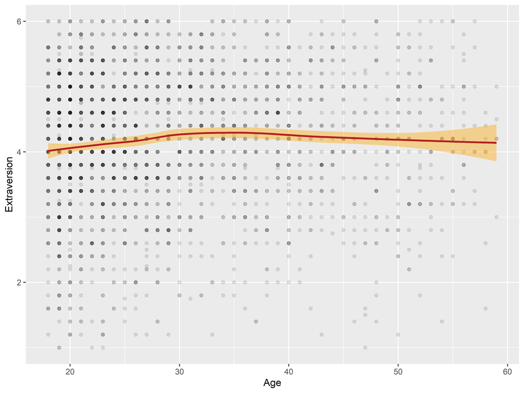

```r
p = ggplot(data.bfi[Age>=18 & Age<60 & !is.na(Edu)],
           aes(x=Age, y=E)) +
  geom_point(alpha=0.1) +
  geom_smooth(method="loess", color="firebrick", fill="orange") +
  labs(y="Extraversion")
p
```

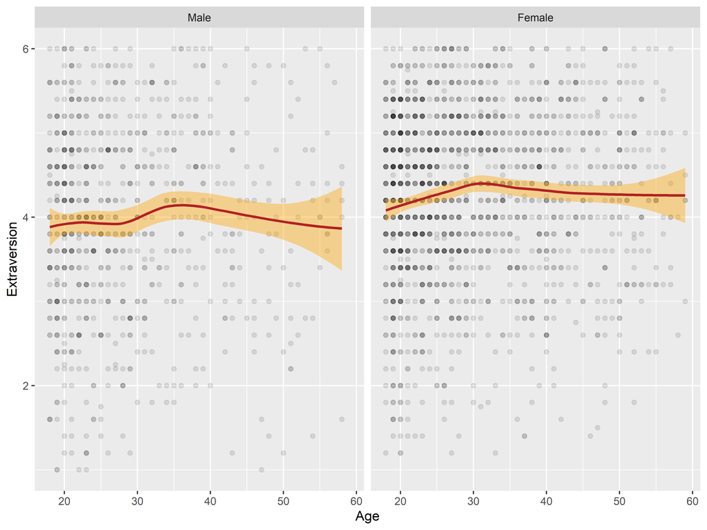

```r
p + facet_wrap(~ Gender)
```

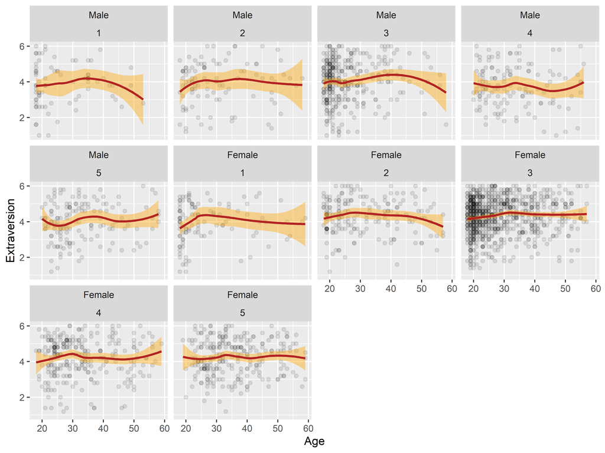

```r
p + facet_wrap(~ Gender + Edu)  # 并不理想
```

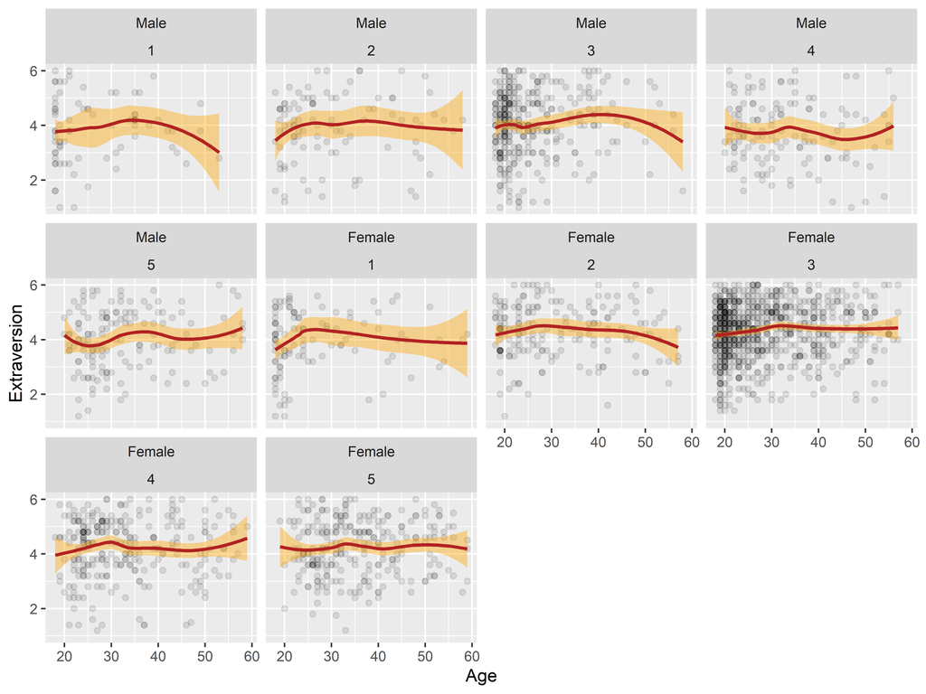

```r
p + facet_wrap(~ Gender * Edu)  # 并不理想
```

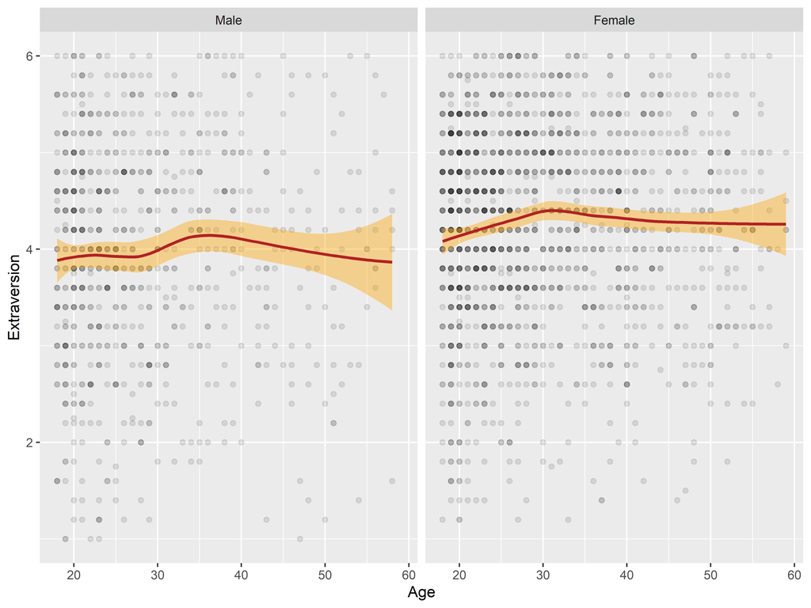

```r
p + facet_grid(~ Gender)  # . ~ 列分组变量（.点可以省略）
```

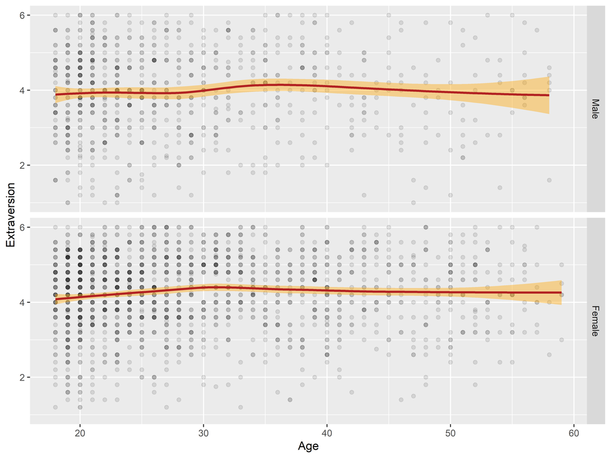

```r
p + facet_grid(Gender ~ .)  # 行分组变量 ~ .（.点不能省略）
```

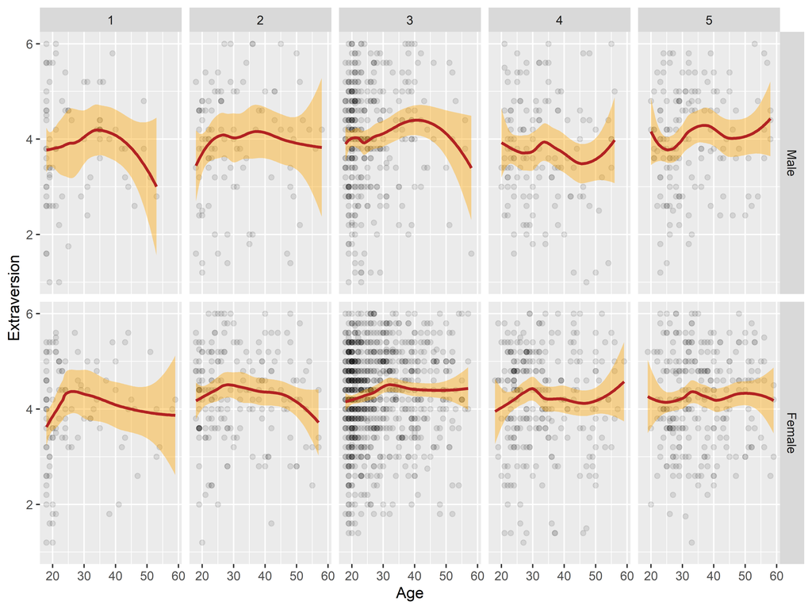

```r
p + facet_grid(Gender ~ Edu)  # 行变量 ~ 列变量
```

```r
p + facet_grid(Edu ~ Gender)  # 行变量 ~ 列变量
```

[figure not shown]

# 多图组合

#### 【实践3】cowplot::plot_grid()：多图组合

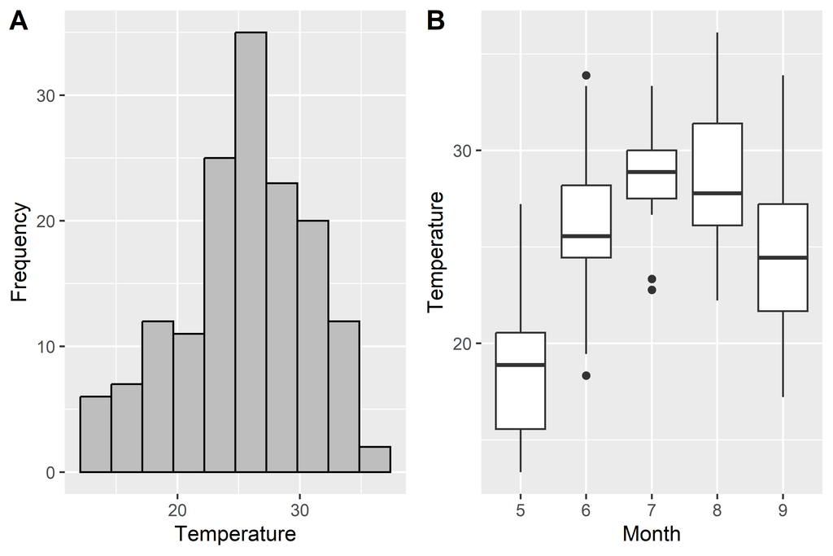

```r
p1 = ggplot(data, aes(x=Temp.C)) +
  geom_histogram(bins=10, color="black", fill="grey") +
  labs(x="Temperature", y="Frequency")

p2 = ggplot(data, aes(x=Month, y=Temp.C)) +
  geom_boxplot() +
  labs(y="Temperature")

p12 = cowplot::plot_grid(p1, p2, nrow=1, labels="AUTO")
p12
```

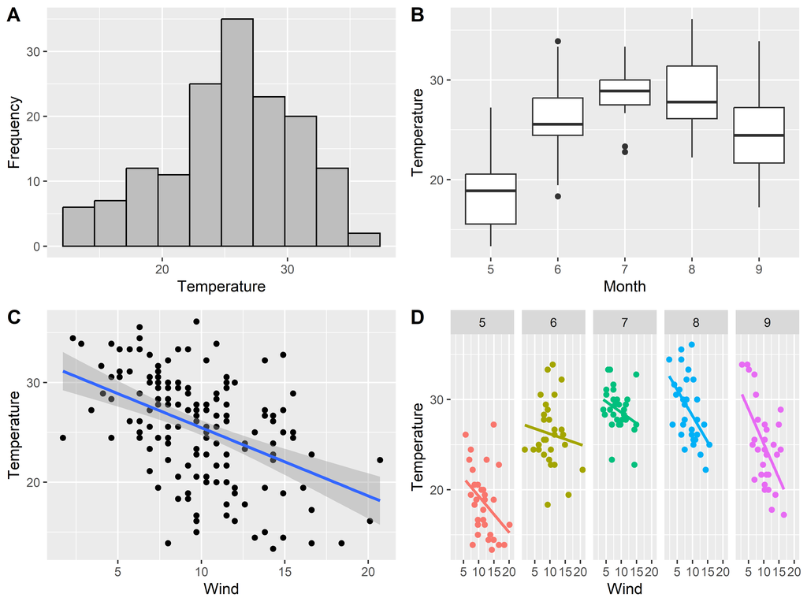

```r
p3 = ggplot(data, aes(x=Wind, y=Temp.C)) +
  geom_point() +
  geom_smooth(method="lm") +
  labs(y="Temperature")

p4 = ggplot(data, aes(x=Wind, y=Temp.C, color=Month)) +
  geom_point(show.legend=FALSE) +
  geom_smooth(method="lm", se=FALSE, show.legend=FALSE) +
  facet_wrap(~ Month, nrow=1) +
  labs(y="Temperature")

p1234 = cowplot::plot_grid(p1, p2, p3, p4, ncol=2, labels="AUTO")
p1234
```

# 图形文件保存

#### 【实践4】ggsave()：图形文件保存

`ggsave()`：保存`ggplot`对象到文件

- `file`：可以是`.png`、`.jpg`、`.pdf`等文件格式
  - PDF格式是矢量图，无限放大依然清晰
- `width`：宽度（英寸inch）
- `height`：高度（英寸inch）
- `dpi`（dots per inch）：每英寸像素点数

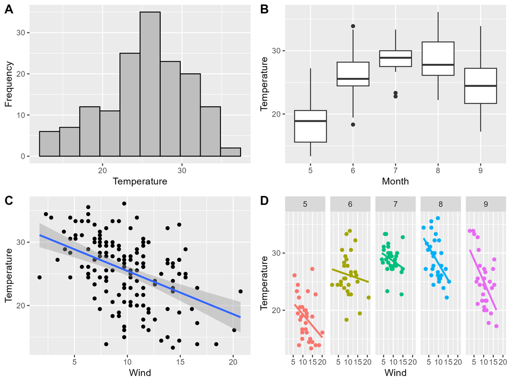

```r
ggsave(p1234, file="Fig1.png", width=8, height=6, dpi=300)
# 分辨率：2400 * 1800（比例合适，分辨率高）
```

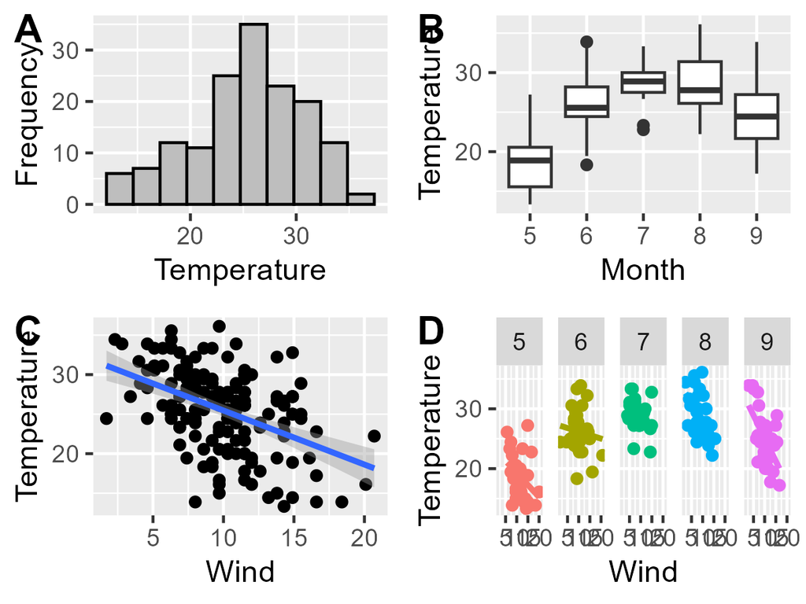

```r
ggsave(p1234, file="Fig2.png", width=4, height=3, dpi=300)
# 分辨率：1200 * 900（比例不合适，虽然分辨率高）
```

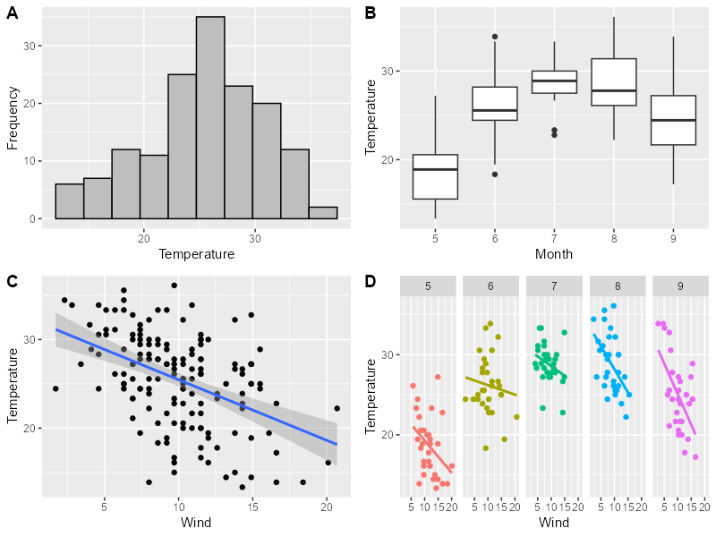

```r
ggsave(p1234, file="Fig3.png", width=8, height=6, dpi=100)
# 分辨率：800 * 600（比例合适，但分辨率低）
```

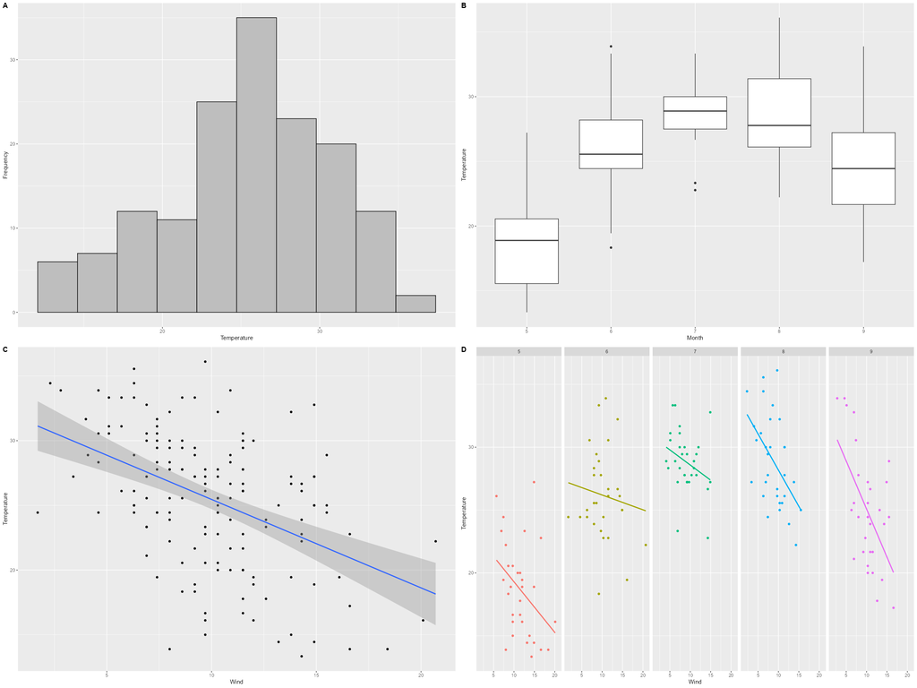

```r
ggsave(p1234, file="Fig4.png", width=24, height=18, dpi=100)
# 分辨率：2400 * 1800（比例不合适，分辨率也低）
```

# 【作业10】多图组合练习

作业要求：

- 使用`cowplot::plot_grid()`函数，把[【作业9】](https://psychbruce.github.io/RCourse/Chap10#%E4%BD%9C%E4%B8%9A9%E5%9F%BA%E7%A1%80%E7%BB%98%E5%9B%BE%E7%BB%83%E4%B9%A0)完成的4张图拼合在一起，添加A~D标签，最后保存为合适尺寸的高清晰度图形文件（`.png`格式，清晰度`dpi`至少为300）
- 使用R Markdown完成，对关键代码及结果要有注释说明

平台提交：

- 关键代码截图及保存的PNG图形

[返回课程主页](https://psychbruce.github.io/RCourse/)

© 包寒吴霜